# Analyze AO Stage Micrometer from BX61

J. R. Minter

Started: 2013-07-16, Last modified: 2019-05-30

Back to ImageJ

I had recorded an image on the Olympus BX-16 microscope at 10X. The metadata from the original image is shown below.

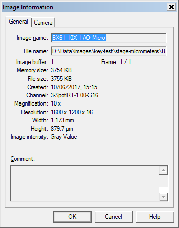

Metadata from SIS Viewer

The image (reduced to 8 bits/pix) is shown below.

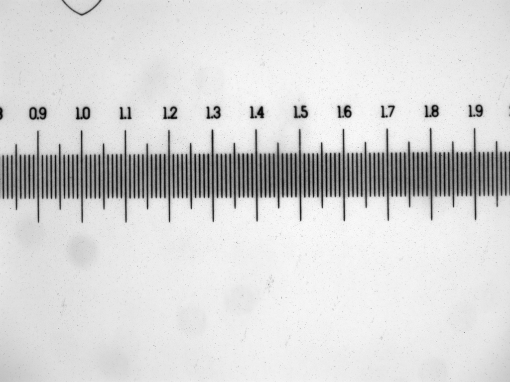

The image reduced to 8 bits per pixel. One large divison is $100\ \mu m$.

The measurement data was stored to a `.csv` file for analysis.

Let’s read in the data

```r
df <-read.csv2("tif/stage-micrometer/BX61-10X-1-AO-micro.csv", sep=',', stringsAsFactors =FALSE)
library(knitr)
kable(df)
```

| ID | Area | Mean | Min | Max | XM | YM |
| --- | --- | --- | --- | --- | --- | --- |
| 1 | 147 | 255 | 255 | 255 | 172.983 | 13.704 |
| 2 | 129 | 255 | 255 | 255 | 310.438 | 13.453 |
| 3 | 140 | 255 | 255 | 255 | 447.214 | 13.550 |
| 4 | 176 | 255 | 255 | 255 | 583.455 | 13.580 |
| 5 | 135 | 255 | 255 | 255 | 720.433 | 12.796 |
| 6 | 145 | 255 | 255 | 255 | 857.769 | 13.521 |
| 7 | 130 | 255 | 255 | 255 | 994.500 | 13.000 |
| 8 | 146 | 255 | 255 | 255 | 1131.829 | 13.356 |
| 9 | 135 | 255 | 255 | 255 | 1268.389 | 12.848 |
| 10 | 137 | 255 | 255 | 255 | 1406.128 | 12.945 |
| 11 | 131 | 255 | 255 | 255 | 36.210 | 14.233 |
| 12 | 1 | 255 | 255 | 255 | 1263.500 | 1.500 |

Note that the area of the last measurement is 1 pixel. This is spurious. We need to filter out the last row.

```r
df_good <- df[df$Area>1,]
kable(df)
```

| ID | Area | Mean | Min | Max | XM | YM |
| --- | --- | --- | --- | --- | --- | --- |
| 1 | 147 | 255 | 255 | 255 | 172.983 | 13.704 |
| 2 | 129 | 255 | 255 | 255 | 310.438 | 13.453 |
| 3 | 140 | 255 | 255 | 255 | 447.214 | 13.550 |
| 4 | 176 | 255 | 255 | 255 | 583.455 | 13.580 |
| 5 | 135 | 255 | 255 | 255 | 720.433 | 12.796 |
| 6 | 145 | 255 | 255 | 255 | 857.769 | 13.521 |
| 7 | 130 | 255 | 255 | 255 | 994.500 | 13.000 |
| 8 | 146 | 255 | 255 | 255 | 1131.829 | 13.356 |
| 9 | 135 | 255 | 255 | 255 | 1268.389 | 12.848 |
| 10 | 137 | 255 | 255 | 255 | 1406.128 | 12.945 |
| 11 | 131 | 255 | 255 | 255 | 36.210 | 14.233 |
| 12 | 1 | 255 | 255 | 255 | 1263.500 | 1.500 |

All we really need is the `XM` columnm, so we can run

```r
df <- df[df$Area>1,]
xm <- as.numeric(df$XM)
xm
```

```
 [1]  172.983  310.438  447.214  583.455  720.433  857.769  994.500
 [8] 1131.829 1268.389 1406.128   36.210
```

Note the last value is unusual…

```r
delta_xm <- diff(xm)
delta_xm
```

```
 [1]   137.455   136.776   136.241   136.978   137.336   136.731   137.329
 [8]   136.560   137.739 -1369.918
```

Yes, the last value is spurious…

```r
delta_xm <- delta_xm[1:9]
delta_xm
```

```
[1] 137.455 136.776 136.241 136.978 137.336 136.731 137.329 136.560 137.739
```

These look as expected. However, they are in units of `px/100 microns`. We really want `microns/px`, so we do a transformation

```r
px_per_um <- 100.0/delta_xm
px_per_um
```

```
[1] 0.7275108 0.7311224 0.7339934 0.7300442 0.7281412 0.7313630 0.7281783
[8] 0.7322789 0.7260108
```

```r
library(dplyr)
med <- median(px_per_um)
std_dev <- sd(px_per_um)

df_px_per_um <- as_tibble(data.frame(statistic=c("median", "std_dev"),
                                 px_per_um=round(c(med, std_dev),4)))
kable(df_px_per_um)
```

| statistic | px_per_um |
| --- | --- |
| median | 0.7300 |
| std_dev | 0.0026 |

Back to ImageJ